# Analyzing Homicide Data by Weather Temperature

Nusrat Nawshin

2021-12-17

# Background

## Overview

Homicide is defined as the act of a human being killing another human. I wanted to study the topic of homicides in the United States for several reasons. While homicides are obviously tragic and unfortunate, the reality is that we are naturally curious about the circumstances surrounding a homicide. The data that I need in order to thoroughly analyze homicide cases in the United States is available thanks to the Murder Accountability Project, a non-profit dedicated to compiling and tracking unsolved homicides nationwide. Founded by investigative journalist and former White House correspondent Thomas Hargrove, the Murder Accountability Project keeps extensive records on homicides and the relevant information surrounding them by gathering information from the FBI, the Department of Justice, and other agencies. The result of their work is a massive set of data that lists relevant information for over 600,000 homicide cases that occurred between 1980 and 2014. The data set includes information on both the victim and perpetrator (sex, age, race, ethnicity) as well as the department that handled the case. It also includes the relationship between the victim and perpetrator, the weapon used in the homicide, and whether that homicide was solved. In addition to the homicide data, I also have access to monthly weather temperature data courtesy of the National Oceanic and Atmospheric Administration that I can use to look at the relationship, if any, between weather and homicide cases.

### Prior Researches

I found some prior researches on this data set. They were mostly researching on the demographic information of the victim and perpetrator. There were some researches on demographic information and the weapon type or type of homicide. Also, some researches based on yearly homicide cases, predicting demographic of victim/perpetrator.

## Dataset Description

[output not shown]

### Limitation of the dataset

In the data set, there isn’t any specific record of the date of the incident. It would have been better if there was exact incident date information. In general, my goal is to find out if there could be any relationship between homicides and weather temperature. To achieve that I needed the temperature data of the homicide cases. I found the monthly average data from the NOAA website. I found three data files over there, Hawaii monthly average temperature data, Alaska monthly average temperature data and another with all other 48 states monthly average temperature data. Joining these three separate data sets, I made a data file with all the 50 states monthly average data and finally joined the monthly average column as ‘temp’ to our main homicide data set. If I had the information of the exact homicide incident date, I could use that day’s average temperature instead of the monthly average temperature. Then the study would have been more accurately compared.

The homicide data set comes from Kaggle and contains roughly 638,000 observations. [Link](https://www.kaggle.com/murderaccountability/homicide-reports)

Additionally, the monthly weather temperature data was collected from NOAA.GOV and contains roughly 75000 records. [Link](https://www.ncdc.noaa.gov/cag/statewide/mapping)

After joining the two datasets and I made the final dataset as “homicide_data.csv”

### Importing data

```r
df <- data.frame(read.csv(unz('homicide_data/homicide_data.zip','homicide_data.csv'), header = T))
# head(df, 5)
str(df)
```

```
## 'data.frame':    638454 obs. of  26 variables:
##  $ X                    : int  1 2 3 4 5 6 7 8 9 10 ...
##  $ Record.ID            : int  80 449 349 346 348 247 368 76 347 78 ...
##  $ Agency.Code          : chr  "AL00102" "AL04500" "AL01800" "AL01800" ...
##  $ Agency.Name          : chr  "Birmingham" "Lowndes" "Cleburne" "Cleburne" ...
##  $ Agency.Type          : chr  "Municipal Police" "Sheriff" "Sheriff" "Sheriff" ...
##  $ City                 : chr  "Jefferson" "Lowndes" "Cleburne" "Cleburne" ...
##  $ State                : chr  "Alabama" "Alabama" "Alabama" "Alabama" ...
##  $ Year                 : int  1980 1980 1980 1980 1980 1980 1980 1980 1980 1980 ...
##  $ Month                : chr  "January" "January" "January" "January" ...
##  $ Incident             : int  7 1 1 1 1 1 1 3 1 5 ...
##  $ Crime.Type           : chr  "Murder or Manslaughter" "Murder or Manslaughter" "Murder or Manslaughter" "Murder or Manslaughter" ...
##  $ Crime.Solved         : chr  "Yes" "Yes" "No" "No" ...
##  $ Victim.Sex           : chr  "Male" "Female" "Male" "Male" ...
##  $ Victim.Age           : int  35 27 99 79 63 55 21 37 77 35 ...
##  $ Victim.Race          : chr  "Black" "Black" "White" "White" ...
##  $ Victim.Ethnicity     : chr  "Unknown" "Unknown" "Unknown" "Unknown" ...
##  $ Perpetrator.Sex      : chr  "Male" "Male" "Unknown" "Unknown" ...
##  $ Perpetrator.Age      : int  30 30 0 0 0 17 23 60 0 30 ...
##  $ Perpetrator.Race     : chr  "White" "Black" "Unknown" "Unknown" ...
##  $ Perpetrator.Ethnicity: chr  "Unknown" "Unknown" "Unknown" "Unknown" ...
##  $ Relationship         : chr  "Stranger" "Wife" "Unknown" "Unknown" ...
##  $ Weapon               : chr  "Handgun" "Shotgun" "Handgun" "Handgun" ...
##  $ Victim.Count         : int  0 0 3 3 3 0 0 0 3 0 ...
##  $ Perpetrator.Count    : int  0 0 1 1 1 0 0 0 1 0 ...
##  $ Record.Source        : chr  "FBI" "FBI" "FBI" "FBI" ...
##  $ temp                 : num  46.7 46.7 46.7 46.7 46.7 46.7 46.7 46.7 46.7 46.7 ...
```

This dataset has 26 variables and 638454 number of observations.

## Homicides on each states

Now I would like to find out if this data set can show some connection between the number of homicides and the weather temperature. But the American state is in three climatic zones therefore it cannot be associated with a single distinctive landscape. There are the great plains affected by desert climate, California luxuriates in soft and warm. Whereas there are Mediterranean weather conditions and people of snow-covered Alaska can admire the aurora. Initially, I wanted to observe this relationship by season type. But the temperature is so versatile in all over the USA that it cannot be generalized that way. That’s why I am sub grouping the temperature by 4 categories for better observations. They are: -

**Freezing**: Temperature < 31F

**Cold**: Temperature between 31F and 68F

**Warm**: Temperature between 68F and 82F

**Hot**: Temperature > 82F

```r
#### Subsetting temperature by value
df_freezing <- subset(df, temp <= 31 )
df_cold <- subset(df, temp > 31 & temp <= 68)
df_warm <- subset(df, temp > 68 & temp <= 82 )
df_hot <- subset(df, temp > 82)
# Categorizing the subsets to Freezing, Cold, Warm, Hot
df_freezing$Weather.Type <- "Freezing"
df_cold$Weather.Type <- "Cold"
df_warm$Weather.Type <- "Warm"
df_hot$Weather.Type <- "Hot"
# joining everything to one dataframe
total_df <- rbind(df_freezing, df_cold)
total_df <- rbind(total_df, df_warm)
total_df <- rbind(total_df, df_hot)
total_df <- total_df[order(total_df$Record.ID),]
#str(total_df)
```

```r
analysis_df <- subset(total_df, select = c(City, State, Year, Month, Incident, Crime.Type, Crime.Solved, Relationship, Weapon, temp, Weather.Type))
# str(analysis_df)

analysis_df$Crime.Solved  = factor(analysis_df$Crime.Solved )
analysis_df$Weather.Type = factor(analysis_df$Weather.Type )
```

After removing the columns that I might not need for this analysis, final data frame summary is:

```r
summary(analysis_df)
```

```
##      City              State                Year         Month
##  Length:638454      Length:638454      Min.   :1980   Length:638454
##  Class :character   Class :character   1st Qu.:1987   Class :character
##  Mode  :character   Mode  :character   Median :1995   Mode  :character
##                                        Mean   :1996
##                                        3rd Qu.:2004
##                                        Max.   :2014
##     Incident    Crime.Type        Crime.Solved Relationship
##  Min.   :  0   Length:638454      No :190282   Length:638454
##  1st Qu.:  1   Class :character   Yes:448172   Class :character
##  Median :  2   Mode  :character                Mode  :character
##  Mean   : 23
##  3rd Qu.: 10
##  Max.   :999
##     Weapon               temp         Weather.Type
##  Length:638454      Min.   :-12.8   Cold    :394238
##  Class :character   1st Qu.: 45.3   Freezing: 48908
##  Mode  :character   Median : 58.5   Hot     : 15407
##                     Mean   : 57.0   Warm    :179901
##                     3rd Qu.: 70.6
##                     Max.   : 89.2
```

At first, let’s check the count of incidents on each weather types.

```r
weatherdata <- table(analysis_df$Weather.Type)
weatherdf <- data.frame(weatherdata)
weatherdf$Freq <- factor(weatherdf$Freq)
```

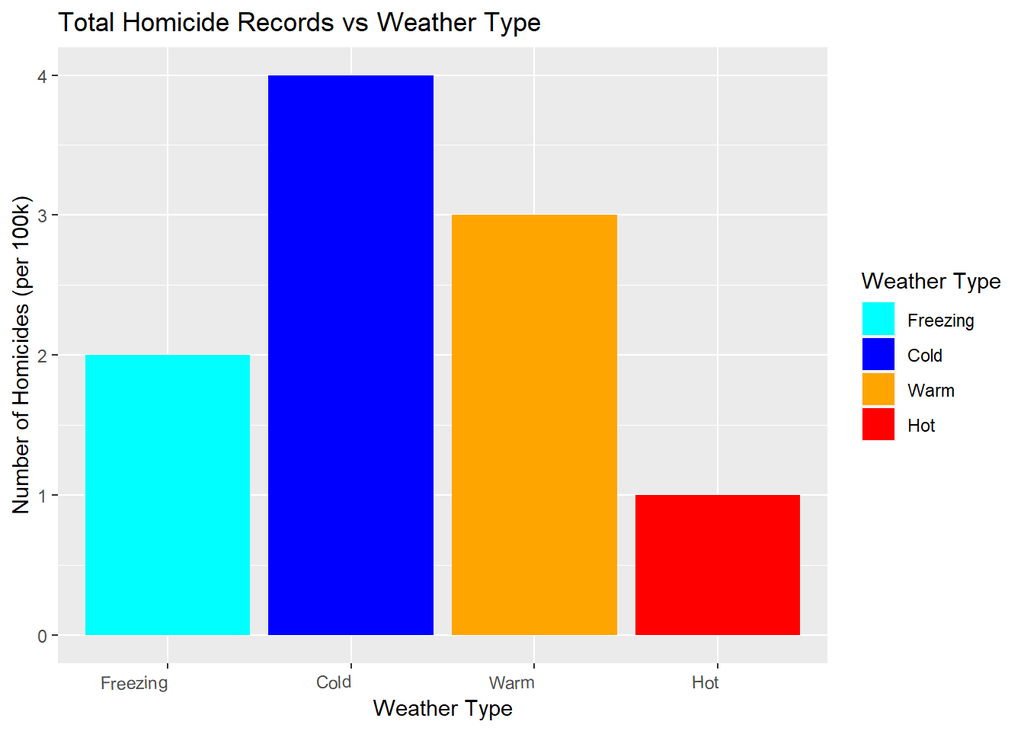

```r
ggplot(weatherdf, aes(y=as.numeric(Freq), x=factor(Var1, level = c("Freezing","Cold","Warm","Hot")), fill=factor(Var1))) +
  geom_bar(stat='identity') +
  scale_fill_manual(breaks = c("Freezing", "Cold", "Warm", "Hot"),
                       values=c("cyan", "blue", "orange", "red"))+
  theme(axis.text.x = element_text(angle = rel(1.5), hjust = 1))+
  labs(title="Total Homicide Records vs Weather Type",
       x="Weather Type",
       y="Number of Homicides (per 100k)",
       fill="Weather Type")
```

Overall, mostly the incidents had happened during cold and warm weather.

Moving on to explore the states and the count of homicides.

```r
table1 <- table(analysis_df$State)
names(table1) <- c("State", "Total.Incidents")
```

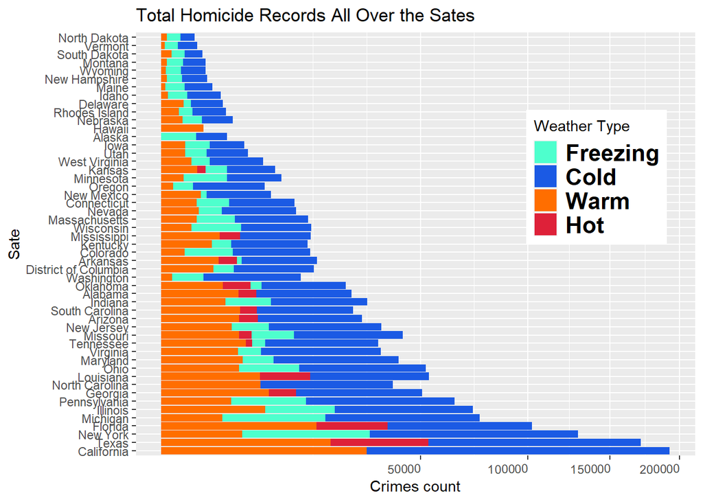

```r
library(ggplot2)
state_data <- as.data.frame(table(analysis_df$Weather.Type, analysis_df$State))
names(state_data) <- c("Weather.Type", "State", "Freq")

ggplot(state_data, aes(reorder(State, -Freq), Freq, fill = Weather.Type)) +
  geom_bar(stat="identity") +
  scale_y_sqrt() +
  scale_fill_manual(breaks = c("Freezing", "Cold", "Warm", "Hot"),
                       values=c("#4effcd", "#1b5ae4", "#ff6e00", "#DE2139")) +
  theme(axis.text.x = element_text(angle = rel(1.5), hjust = 1),
        legend.justification=c(1,0),
        legend.position=c(0.95,0.5),
        legend.text = element_text(size = rel(1.5), face = "bold"))+
  coord_flip()+
  labs(title="Total Homicide Records All Over the Sates",
       x="Sate",
       y="Crimes count",
       fill="Weather Type")
```

```r
#ggsave("myplot.png")
```

Top 5 states in most homicide cases are:

1. California
2. Texas
3. New York
4. Florida
5. Michigan

Top 5 states in least homicide cases are:

1. North Dakota
2. Vermont
3. South Dakota
4. Montana
5. Wyoming

## Homicides over the years

Now let’s observe the homicides by years and weather types.

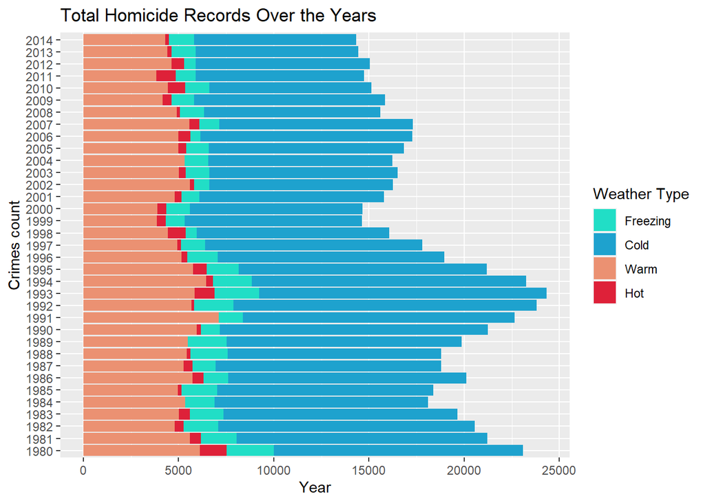

```r
ggplot(analysis_df, aes(x=as.factor(Year), fill=Weather.Type )) +
  geom_bar( ) +
  scale_fill_hue(c = 30) +
  coord_flip()+
  scale_fill_manual(breaks = c("Freezing", "Cold", "Warm", "Hot"),
                       values=c("#21dec6", "#1EA2CE", "#EB9172", "#DE2139"))+
  labs(title="Total Homicide Records Over the Years",
       x="Crimes count",
       y="Year",
       fill="Weather Type")
```

It can be also observed that, there’s a significant drop of cases after 1993. After that it started to decrease gradually till the end of the century. The homicide cases in the 21st century were comparatively lower than the 20th. Maybe it could be the technological advancement that 21st century, people were more focused on the changes than committing homicides.

### $chi$-squared test

To find out the correlation between count of homicides and weather type, we are doing a $chi$-squared test on weather type and count of homicides with a null hypothesis that Weather Type and number of homicides are independent.

```r
monthlycrimedata <- table( analysis_df$State,analysis_df$Year, analysis_df$Month, analysis_df$Weather.Type)
monthlycrimedf <- as.data.frame(monthlycrimedata)
monthlycrimedf$Freq <- factor(monthlycrimedf$Freq)
#str(monthlycrimedf)
```

```r
contable=table(monthlycrimedf$Var4, monthlycrimedf$Freq)

chitest = chisq.test(contable)
chitest
```

```
##
##  Pearson's Chi-squared test
##
## data:  contable
## X-squared = 23407, df = 1029, p-value <2e-16
```

Given this p-value of 0 is less than the alpha of 0.05, we reject the null hypothesis that Weather Type and number of homicides are independent. We conclude that there is an evidence that the two variables are dependent (i.e., that there is an association between the two variables).

Now, we are going to check if there is any relationship between weather type and number of homicides by generating a correlation matrix.

### Correlation Matrix

**Correlation between incident, year and weather type:**

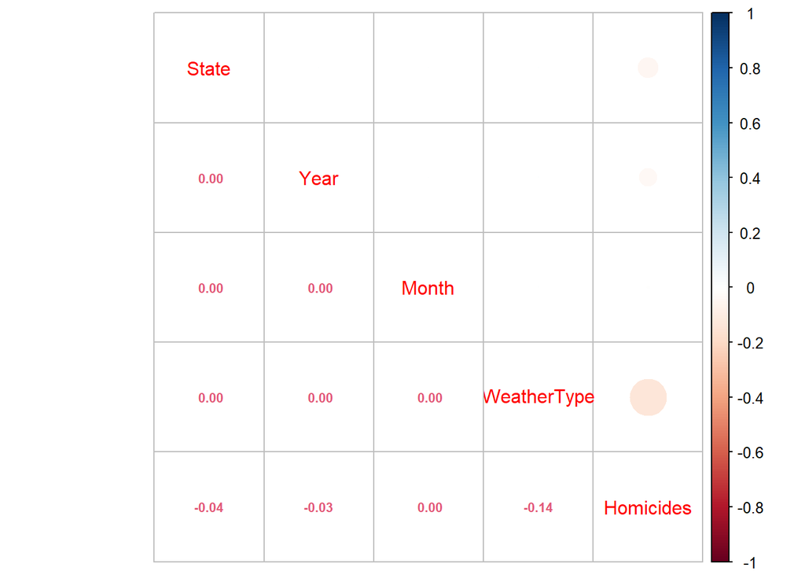

```r
numericdata <- data.frame(monthlycrimedf)
numericdata$Var1 <- cbind(as.numeric(numericdata$Var1))
numericdata$Var2 <- as.numeric(numericdata$Var2)
numericdata$Var3 <- as.numeric(numericdata$Var3)
numericdata$Var4 <- as.numeric(numericdata$Var4)
numericdata$Freq <- as.numeric(numericdata$Freq)
colnames(numericdata)[0:5] = c("State","Year","Month","WeatherType","Homicides")
cormatrix = cor(numericdata)
corrplot.mixed(cormatrix,lower.col = "#e25978", number.cex = .7)
```

# Conclusion

Overall, there isn’t that much of relationship between number of homicides and the weather type that I have assumed from the beginning. As USA has a very diverse climate, our data set couldn’t give that many insights of it. Also, as I had to use monthly average data of the state on analyze, it cannot precisely give the incident day temperature.